# Recitation week 3

Eric R. Scott

### Warmup

- Take a random sample of 15 *integers* from a sequence of *integers* ranging from 1 to 1000.
- Take a random sample of 15 numbers from a normal distribution with a mean of 500 and a standard deviation of 10
- What are some of the differences between sampling numberse these two ways?

### Discrete probability distributions

Remember to plot these as barplots with space between the bars, not as histograms or as lines

#### Uniform

`dunif()` gives the probability of a single event, e.g. probability of rolling a 6 on a single die. This is pretty easy to do with math instead.

```r
#die
dunif(5, min = 0, max = 6)
```

```
[1] 0.1666667
```

```r
#Naming arguments can be helpful, but you don't have to do it if you supply them in the same order as in the helpfile
dunif(5, 0, 6)
```

```
[1] 0.1666667
```

```r
1/6
```

```
[1] 0.1666667
```

`punif()` gives the probability distribution function. E.g. P[X < 5] or P[X > 3].

- Read the help file to figure out what `lower.tail` does.

```r
#proability of rolling 1 through 4
punif(4, min = 0, max = 6, lower.tail = TRUE)
```

```
[1] 0.6666667
```

```r
#probability of rolling greater than 4
punif(4, min = 0, max = 6, lower.tail = FALSE)
```

```
[1] 0.3333333
```

All of this is easy to do with math, but all probability distributions use similar functions. That is, there’s a `pbinom()`, a `pnorm()`, a `ppois()` (for poisson, which we won’t cover), etc.

#### Plotting a discrete probability distribution

How does `barplot()` work? Look at help file. Notice that there are *MANY* arguments, but that all but one have defaults. That means you don’t need to worry about them! Notice that rather than x and y it wants “height”. That means it isn’t going to calculate anything for you the way `boxplot()` does!

```r
#make a vector of heights
(probs <- dunif(1:6, min = 0, max = 6))  #parentheses make it show the result AND assign to object
```

```
[1] 0.1666667 0.1666667 0.1666667 0.1666667 0.1666667 0.1666667
```

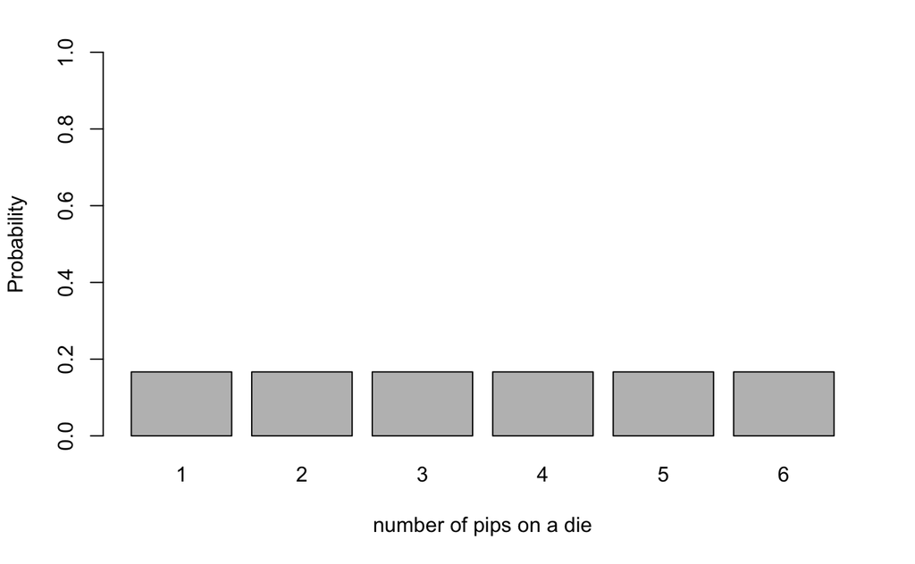

```r
barplot(height = probs,
        names.arg = 1:6,         #add names.arg to get x-axis labels
        ylim = c(0,1),           #xlim and ylim change the range of the axes.
        ylab = "Probability",
        xlab = "number of pips on a die")
```

#### Binomial Distribution

Number of times one of two mutually exclusive events occurs in n independent trials Take a look at the helpfile for `dbinom()`

- Which argument is #trials? (size)
- which argument is binomial p AKA p[success] ? (prob)

10 coin tosses, P[X = 5 heads]

```r
dbinom(x = 5, size = 10, prob = 0.5)
```

```
[1] 0.2460938
```

probability of germinating titan arum seeds

```r
p <- 0.30
n <- 3
x <- 0:3
(probs <- dbinom(0:3, n, p))
```

```
[1] 0.343 0.441 0.189 0.027
```

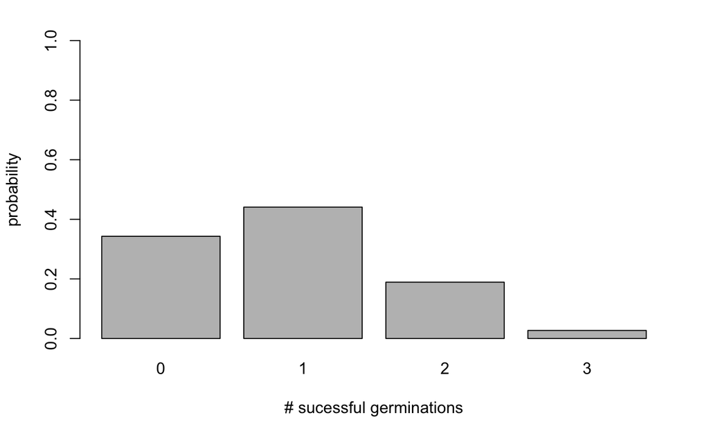

```r
barplot(height = probs, names.arg = 0:3,
        xlab = "# sucessful germinations",
        ylab = "probability",
        ylim = c(0,1))
```

Play with shape of binomial distribution

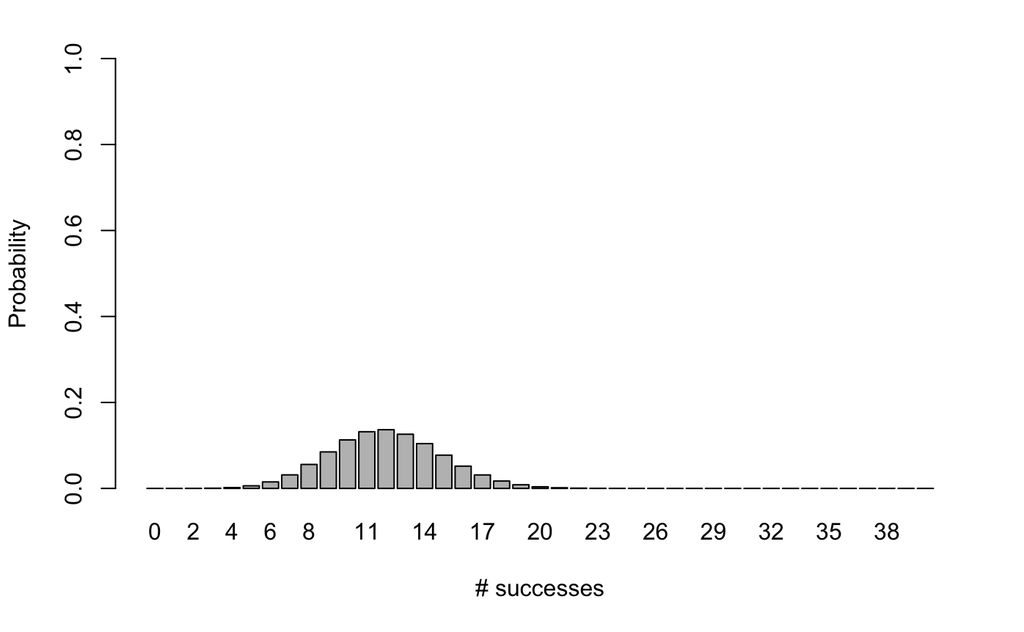

```r
p = 0.3
n = 40
x = 0:n
probs <- dbinom(x, n, p)
barplot(probs, names.arg = x, ylim = c(0,1),
        ylab = "Probability",
        xlab = "# successes")
```

**Advanced** barplots. Recreating a figure from lecture slides showing how binomial distributions change when parameters change.

```r
n = 20
x = 0:n
p1 <- dbinom(x, n, 0.1)
p2 <- dbinom(x, n, 0.5)
p3 <- dbinom(x, n, 0.9)
#add = argument allows overplotting.  Not perfect because green bars cover red bars and blue covers green not side-by side.
#gold star for anyone who figures out how to do this correctly!
barplot(p1, col = "red", ylim = c(0, 0.3), names.arg = 0:n)
barplot(p2, col = "green", add = TRUE, axes = FALSE)
```

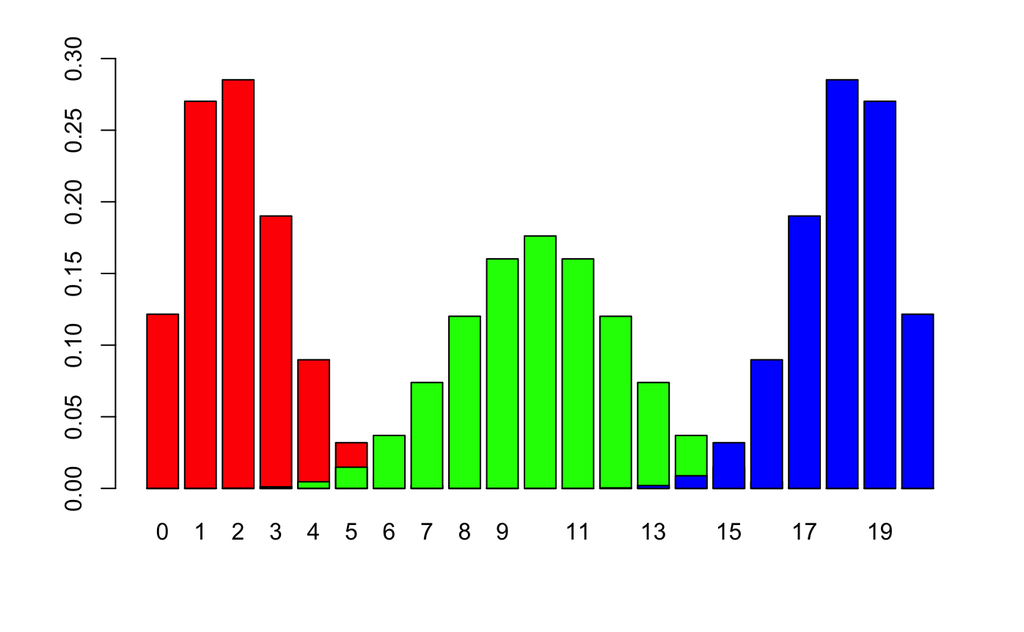

```r
barplot(p3, col = "blue", add = TRUE, axes = FALSE)
```

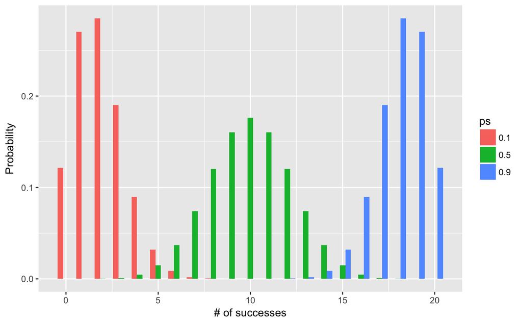

```r
###ggplot2 way.  To run this, you might need to install ggplot2 using install.packages("ggplot2")
df <- data.frame(probs = c(p1, p2, p3), #one column is all the calculated probabilities
                 ps = rep(c("0.1", "0.5", "0.9"), each = 21), #one column is the probabilities of success
                 xs = rep(0:20, 3)) #one column is just 0 - number of trials to be used as the x-axis
library(ggplot2)
ggplot(df) +
  geom_col(aes(y = probs, x = xs, fill = ps), position = "dodge") +
  #position = "dodge" makes the bars not overlap,
  #fill = makes it color code by that variable
  xlab("# of successes") +
  ylab("Probability")
```

#### Exercise 1

- What’s the probability of drawing an ace of spades from a deck of cards (with no Jokers)?
- What’s the probability of drawing 5 aces (of any suit) in a row from a deck of cards (with replacement!)?

```r
#prob of 5 aces out of 5 draws (with replacement)
n = 5
p = 4/52
x = 5
dbinom(x, n, p)
```

```
[1] 2.693291e-06
```

### Continuous distributions

probability is area under the curve

#### Normal

- what are the defaults for mean and sigma for `pnorm()`? which normal distribution is this?
- Don’t use `dnorm()`!

```r
#P[X = x] is always 0
dnorm(1)
```

```
[1] 0.2419707
```

```r
#doesn't work like expected!  Don't use dnorm!
```

- what % of curve is between -2 and 2 standard deviations?

```r
pnorm(2) #only lower tail, not between. Draw on board
```

```
[1] 0.9772499
```

```r
pnorm(2) - pnorm(-2) #subtract the lower bit
```

```
[1] 0.9544997
```

#### Plotting continuous distributions

You could use points to approximate the shape

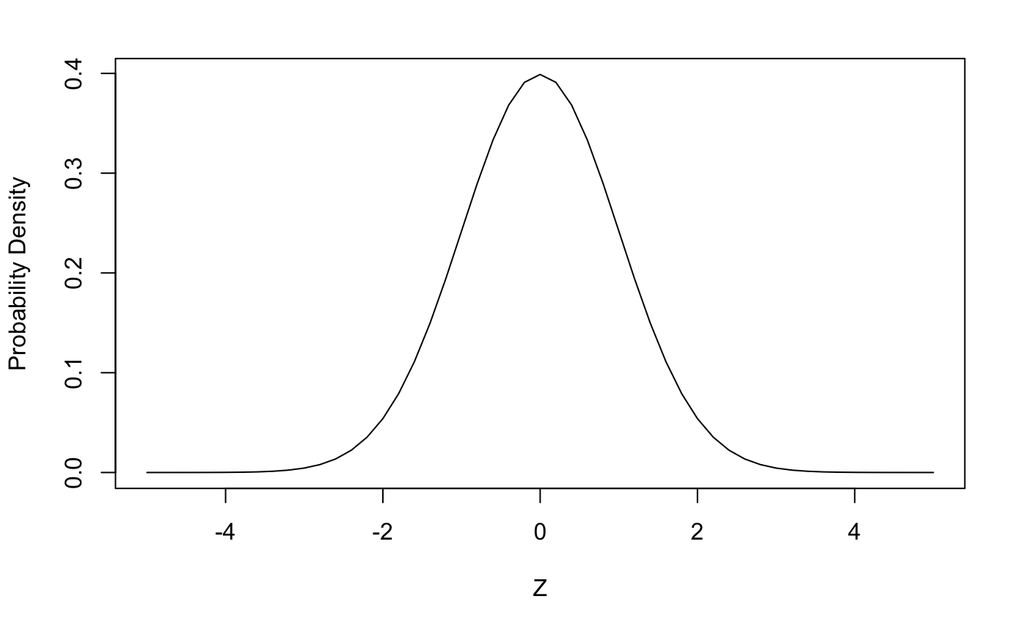

```r
xvals <- seq(-5, 5, 0.2) #just a sequence of x values to get probabilities for
plot(x = xvals, y = dnorm(xvals),
     ylab = "Probability Density",
     xlab = "Z",
     type = "l") #line plot instead of points
```

Another way is to use `curve()` which takes a function as the first argument

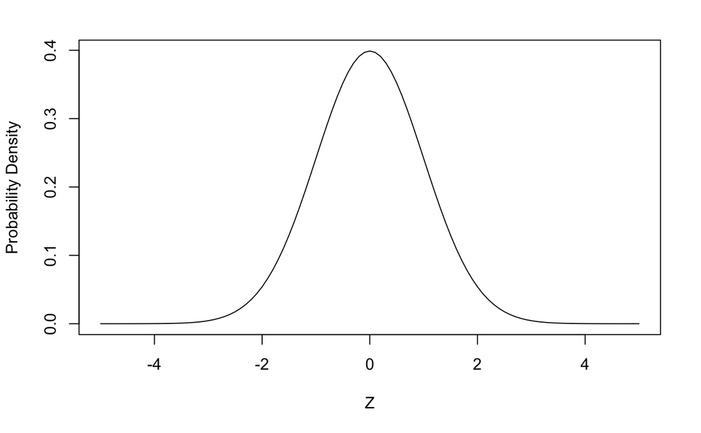

```r
curve(dnorm(x), from = -5, to = 5,
      ylab = "Probability Density",
      xlab = "Z")
```

```r
#could also use add = TRUE to overlay ontop of scatter plot
```

**Advanced** plotting: adding vertical lines and colors and arrows and text to a plot

```r
curve(dnorm(x), from = -5, to = 5,
      ylab = "Probability Density",
      xlab = "Z",
      col = "blue")
abline(v = -2, col = "red")
```

[output not shown]